# DataCamp Assignment

This is an [DataCampt](http://www.datacamp.com) Assignment Notebook for EdX Inferential and Modelling course Section 6 offered by Harvaard University.

```r
# Load the libraries and poll data
library(dplyr)
library(dslabs)
library(tidyverse)
data(heights)
```

## Exercise 1 - Using the t-Distribution

We know that, with a normal distribution, only 5% of values are more than 2 standard deviations away from the mean.

Calculate the probability of seeing t-distributed random variables being more than 2 in absolute value when the degrees of freedom are 3.

### Instructions

- Use the `pt` function to calculate the probability of seeing a value less than or equal to the argument. Your output should be a single value.

```r
# Calculate the probability of seeing t-distributed random variables being more than 2 in absolute value when 'df = 3'.
pt(-2, df = 3) + 1 - pt(2, df = 3)
```

```
[1] 0.139
```

## Exercise 2 - Plotting the t-distribution

Now use sapply to compute the same probability for degrees of freedom from 3 to 50.

Make a plot and notice when this probability converges to the normal distribution’s 5%.

### Instructions

- Make a vector called `df` that contains a sequence of numbers from 3 to 50.
- Using function, make a function called `pt_func` that recreates the calculation for the probability that a value is greater than 2 as an absolute value for any given degrees of freedom.
- Use `sapply` to apply the `pt_func` function across all values contained in `df`. Call these probabilities probs.
- Use the `plot` function to plot `df` on the x-axis and probs on the y-axis.

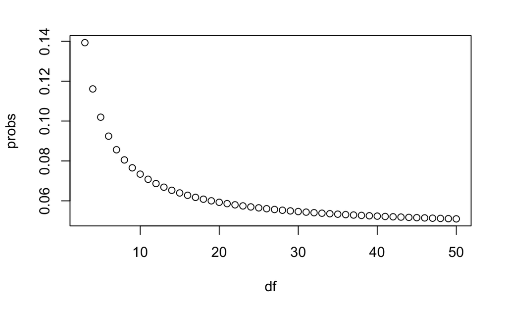

```r
# Generate a vector 'df' that contains a sequence of numbers from 3 to 50
df <- seq(3, 50)

# Make a function called 'pt_func' that calculates the probability that a value is more than |2| for any degrees of freedom
pt_func <- function(d) {
    1 - pt(2, df=d) + pt(-2, df=d)
}

# Generate a vector 'probs' that uses the `pt_func` function to calculate the probabilities
probs <- sapply(X = df, FUN = pt_func)

# Plot 'df' on the x-axis and 'probs' on the y-axis
plot(df, probs)
```

## Exercise 3 - Sampling From the Normal Distribution

In a previous section, we repeatedly took random samples of 50 heights from a distribution of heights. We noticed that about 95% of the samples had confidence intervals spanning the true population mean.

Re-do this Monte Carlo simulation, but now instead of $N = 50$, use $N = 15$. Notice what happens to the proportion of hits.

### Instructions

- Use the `replicate` function to carry out the simulation. Specify the number of times you want the code to run and, within brackets, the three lines of code that should run.
- First use the `sample` function to randomly sample N values from x.
- Second, create a vector called `interval` that calculates the 95% confidence interval for the sample. You will use the `qnorm` function.
- Third, use the `between` function to determine if the population mean mu is contained between the confidence intervals.
- Save the results of the Monte Carlo function to a vector called `res`.
- Use the `mean` function to determine the proportion of hits in `res`.

```r
# Use the sample code to generate 'x', a vector of male heights
x <- heights %>% filter(sex == "Male") %>%
  .$height

# Create variables for the mean height 'mu', the sample size 'N', and the number of times the simulation should run 'B'
mu <- mean(x)
N <- 15
B <- 10000

# Use the `set.seed` function to make sure your answer matches the expected result after random sampling
set.seed(1)

# Generate a logical vector 'res' that contains the results of the simulations
res <- replicate(B, {
    smpl <- sample(x, N, replace=TRUE)
    interval <- c(mean(smpl) - qnorm(0.975) * sd(smpl)/sqrt(N),
                  mean(smpl) + qnorm(0.975) * sd(smpl)/sqrt(N))
    between(mu, interval[1], interval[2])
})

# Calculate the proportion of times the simulation produced values within the 95% confidence interval. Print this value to the console.
mean(res)
```

```
[1] 0.9331
```

Exercise 4 - Sampling from the t-Distribution $N = 15$ is not that big. We know that heights are normally distributed, so the t-distribution should apply. Repeat the previous Monte Carlo simulation using the t-distribution instead of using the normal distribution to construct the confidence intervals.

What are the proportion of 95% confidence intervals that span the actual mean height now?

### Instructions

- Use the `replicate` function to carry out the simulation. Specify the number of times you want the code to run and, within brackets, the three lines of code that should run.
- First use the `sample` function to randomly `sample` `N` values from `x.`
- Second, create a vector called interval that calculates the 95% confidence interval for the `sample.` Remember to use the qt function this time to generate the confidence interval.
- Third, use the between function to determine if the population mean mu is contained between the confidence intervals.
- Save the results of the Monte Carlo function to a vector called `res.`
- Use the `mean` function to determine the proportion of hits in `res.`

```r
# The vector of filtered heights 'x' has already been loaded for you. Calculate the mean.
mu <- mean(x)

# Use the same sampling parameters as in the previous exercise.
set.seed(1)
N <- 15
B <- 10000

# Generate a logical vector 'res' that contains the results of the simulations using the t-distribution
res <- replicate(B, {
    smpl <- sample(x, N, replace=TRUE)
    interval <- c(mean(smpl) - qt(0.975, df=N-1) * sd(smpl)/sqrt(N),
                  mean(smpl) + qt(0.975, df=N-1) * sd(smpl)/sqrt(N))
    between(mu, interval[1], interval[2])
})

# Calculate the proportion of times the simulation produced values within the 95% confidence interval. Print this value to the console.
mean(res)
```

```
[1] 0.9512
```